# Lecture 1 Exercises

## Short Questions

1. What is the difference between a list and an array?
2. Consider the list

`list_colors = ["red","yellow","green"]`

What is the output of `list_colors[0]` and  
`list_colors[1]`?

3. How do you concatenate two strings?
4. What does the error "not defined" mean?
5. What does the error "could not be broadcast" mean?
6. How do you compute the median of an array?

```python
# Write your answers here as comments:

#1 List can be a combination of different types of data.  For instance, it can be numerical [1, 2, 3..] + intr ["orage", ] +[true]
# On the otherhand array will be only numerical data type.  For example: [1, 2, 3]

list_color = ["red", "yellow", "green", "blue", 1, 2, 3, 4, 5]
print (list_color)

my_array = np.array([10, 20, 30])
print (my_array)

#2 list_color[0] = "red", in python index start from 0 while in R index start from 1. list_color[1] = "yellow"
list_color[0] # "red"

#3 Concatenate two strings:  first = "Parimal", last = "Majumder", name = (first + last), print (name)
first = "Parimal"
last = "Majumder"
name = first + " " + last
print (name)

#4 In python not defined mean, was not assigned properly , for instance , "name" has to defined and stored.
# my_name = ?, here my name was not defined

#5 Error could not broadcast input array from shape (3,) into shape (2,).

# Python is trying to do math with two arrays, but their sizes/shapes don't fit together.
'''a = np.array([1, 2, 3])
b = np.array([10, 20])
here a +b cannot be done because the shapes of the arrays are different. a has 3 elements and b has 2 elements.  So, it will give an error.
'''

# #6. import numpy as np
import numpy as np
```

```
['red', 'yellow', 'green', 'blue', 1, 2, 3, 4, 5]
[10 20 30]
Parimal Majumder
```

## Long Questions

(a) Import the pandas, matplotlib, and numpy packages

```python
# Write your own code

import numpy as np
import matplotlib.pyplot as plt
import pandas as pd
```

(b) Open the dataset "worldbank_wdi_2019.csv"  
in the "data" folder

- Read it as a pandas object called "wdi"
- Note: This is a subset of the World Development Indicators for 2019
- Each observation represents a different country

```python
# Write your own code
# Import a CSV file (READ)
World_bank = pd.read_csv("data/worldbank_wdi_2019.csv")

# Save the dataset to another csv file (WRITE)
World_bank.to_csv("data/features_stored.csv")


World_bank
```

|  | year | country_name | life_expectancy | gdp_per_capita_usd |
| --- | --- | --- | --- | --- |
| 0 | 2019 | Afghanistan | 63.565 | 500.522664 |
| 1 | 2019 | Albania | 79.282 | 5396.215864 |
| 2 | 2019 | Algeria | 76.474 | 4022.150184 |
| 3 | 2019 | American Samoa | NaN | 13672.576660 |
| 4 | 2019 | Andorra | NaN | 41327.502030 |
| ... | ... | ... | ... | ... |
| 266 | NaN | NaN | NaN | NaN |
| 267 | NaN | NaN | NaN | NaN |
| 268 | NaN | NaN | NaN | NaN |
| 269 | Data from database: World Development Indicators | NaN | NaN | NaN |
| 270 | Last Updated: 12/22/2022 | NaN | NaN | NaN |

271 rows × 4 columns

(c) Browse the dataset and manually create  
a list of variable names

```python
# Write your own code

# Create a list, e.g. "variable_names = [ "name1", "name2", "name3" ]"
# Manually type the names of the variables
# If you're viewing the dataset from the VS-Code "Variables" tool, you'll
# see an extra column "index". Do not include this in your list.

list_names = list(World_bank)
print(list_names)
list_names[3]
World_bank[list_names[3]]   # gdp_per_capita_usd
```

```
['year', 'country_name', 'life_expectancy', 'gdp_per_capita_usd']
```

```
0        500.522664
1       5396.215864
2       4022.150184
3      13672.576660
4      41327.502030
           ...
266             NaN
267             NaN
268             NaN
269             NaN
270             NaN
Name: gdp_per_capita_usd, Length: 271, dtype: float64
```

```python
World_bank[[list_names[1], list_names[3]]] # as the practice , add two columns togeter
```

|  | country_name | gdp_per_capita_usd |
| --- | --- | --- |
| 0 | Afghanistan | 500.522664 |
| 1 | Albania | 5396.215864 |
| 2 | Algeria | 4022.150184 |
| 3 | American Samoa | 13672.576660 |
| 4 | Andorra | 41327.502030 |
| ... | ... | ... |
| 266 | NaN | NaN |
| 267 | NaN | NaN |
| 268 | NaN | NaN |
| 269 | NaN | NaN |
| 270 | NaN | NaN |

271 rows × 2 columns

(d) Compute descriptive statistics for the fourth  
variable in the dataset

- One way to do this is:

wdi["gdp_per_capita_usd"].describe()

- Do something similar, but with the list you created above.
- Substitute "gdp_per_capita_usd" with a command that  
  automatically extracts the fourth element in the list

```python
World_bank[list_names[3]].describe()
```

```
count       255.000000
mean      17230.949757
std       25792.183785
min         216.972968
25%        2186.046581
50%        6837.717826
75%       19809.323135
max      199377.481800
Name: gdp_per_capita_usd, dtype: float64
```

```python
# Write your own code

# Remember that the numbering in Python starts at zero
# For example:
# list_colors = ["red","green","yellow"]
# list_colors[2] will output "yellow"


All_colors = ["red", "yellow", "blue", "green"]
All_colors
All_colors[2] #index start with 0, 1, 2, therefore 2 position is positioned of "blue"
```

```
'blue'
```

(e) Show a scatter plot that shows "gdp_per_capita_usd"  
in the x-axis and "lifexpectancy" in the y-axis. Label the axes.

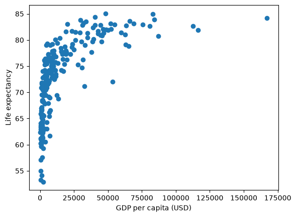

```python
# Write your own code
# need to import matplotlib.pyplot as plt

plt.scatter(World_bank["gdp_per_capita_usd"], World_bank["life_expectancy"])

plt.xlabel("GDP per capita (USD)")
plt.ylabel("Life expectancy")

plt.show()
```

(f) Generate "vec_x" from a chi-square  
distribution with (df = 1, size = 1000)

- Plot a histogram of each variable, with axis labels, and title
- Create a new variable "vec_y" by the formula  
  $ y = e^x + 2x + 5$
- Plot "vec_x" against "vec_y" and label the axes

```python
# Write your own code
# import numpy as np
vec_x = np.random.chisquare(df=1, size=1000)
print (vec_x)
len(vec_x)
```

[output not shown]

[output cut: 195 more lines]

[output not shown]

```
1000
```

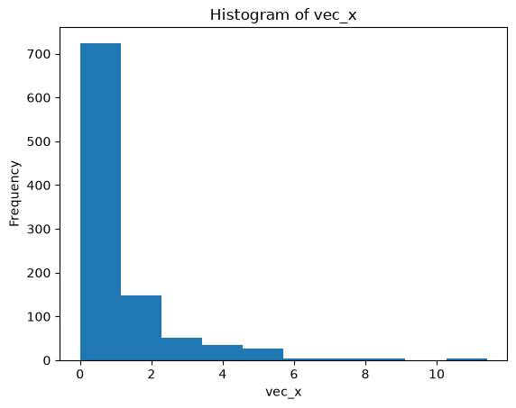

```python
plt.hist(vec_x)
plt.xlabel("vec_x")
plt.ylabel("Frequency")
plt.title("Histogram of vec_x")
plt.show()

# Formula is given : y=ex+2x+5
# Create the variable: vec_y, vec_x against vec_y and label the axes.

vec_y = np.exp(vec_x) + 2*vec_x + 5
```

```python
# Formula is given : y=ex+2x+5
# np.exp(vec_x) →  eˣ, 2*vec_x →  2x, 5 →  +5
vec_y = np.exp(vec_x) + 2*vec_x + 5
print(vec_y)
len(vec_y)
```

[output not shown]

[output cut: 195 more lines]

[output not shown]

```
1000
```

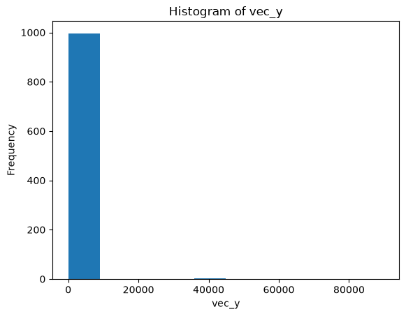

```python
# Created a variable vec_y using above code and here x axis is vec_y

plt.hist(vec_y)
plt.xlabel("vec_y")
plt.ylabel("Frequency")
plt.title("Histogram of vec_y")
plt.show()
```

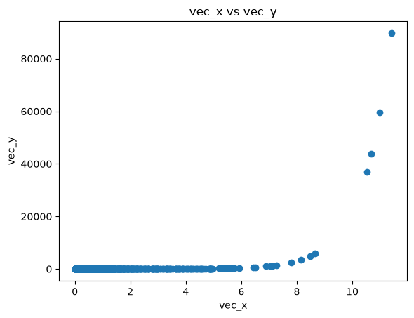

```python
#Plot vec_x against vec_y and label the axes

plt.scatter(vec_x, vec_y)

plt.xlabel("vec_x")
plt.ylabel("vec_y")
plt.title("vec_x vs vec_y")

plt.show()
```

(g) Research online how to create an array with  
`size = 1000` entries, with all entries equal to one.

- Create a new matrix, `X_mat` that appends a  
  vector with only ones and "vec_x" from question (f) to form  
  a matrix with two columns and 1000 rows
- Compute $(X_{mat}'X_{mat})^{-1}$

```python
# Write your own code

vec_ones = np.ones(1000)
print(vec_ones)
len(vec_ones) # checked length of the vector, it is 1000, as expected
vec_ones.shape
vec_ones.shape
```

[output not shown]

```python
X_mat = np.column_stack((vec_ones, vec_x))
print(X_mat)
X_mat.shape
```

```
[[ 1.          1.68125638]
 [ 1.          0.34442357]
 [ 1.          0.21977833]
 ...
 [ 1.          0.49625037]
 [ 1.         11.40485737]
 [ 1.          1.02812198]]
```

```
(1000, 2)
```

```python
#X_mat.T → transpose of X_mat,
# @ → matrix multiplication
# np.linalg.inv(...) → matrix inverse

result = np.linalg.inv(X_mat.T @ X_mat)
print(result) # here result is a 2x2 matrix, which is the inverse of the product of the transpose of X_mat and X_mat itself. This is often used in linear regression calculations to find the coefficients of the regression line.
```

```
[[ 0.00146226 -0.0004524 ]
 [-0.0004524   0.00044276]]
```